# Classification examples

# Setup libs and environment

```r
library(tidyverse)
library(keras)
library(brms)
library(janitor)
library(kableExtra)
library(corrplot)
library(caret)
library(pscl)
ggplot2::theme_set(theme_classic(base_size = 18))
options(scipen = 999999)
knitr::opts_chunk$set(fig.width = 5, fig.height = 3, dpi = 300)
```

# Titanic dataset

Taken from https://www.kaggle.com/code/dmilla/introduction-to-decision-trees-titanic-dataset

## Load the data

```r
titanic <- read_csv("input/titanic/titanic.csv") |>
  clean_names()
```

## Data exploration

### Show me what you got

Each row shows a single passenger, if they survived, their class, name, sex, age, no. siblings, N. parents/childred, ticket number & fare cost.

```r
titanic |>
  head() |>
  kbl() |>
  kable_classic()
```

| passenger_id | survived | pclass | name | sex | age | sib_sp | parch | ticket | fare | cabin | embarked |
| --- | --- | --- | --- | --- | --- | --- | --- | --- | --- | --- | --- |
| 1 | 0 | 3 | Braund, Mr. Owen Harris | male | 22 | 1 | 0 | A/5 21171 | 7.2500 | NA | S |
| 2 | 1 | 1 | Cumings, Mrs. John Bradley (Florence Briggs Thayer) | female | 38 | 1 | 0 | PC 17599 | 71.2833 | C85 | C |
| 3 | 1 | 3 | Heikkinen, Miss. Laina | female | 26 | 0 | 0 | STON/O2. 3101282 | 7.9250 | NA | S |
| 4 | 1 | 1 | Futrelle, Mrs. Jacques Heath (Lily May Peel) | female | 35 | 1 | 0 | 113803 | 53.1000 | C123 | S |
| 5 | 0 | 3 | Allen, Mr. William Henry | male | 35 | 0 | 0 | 373450 | 8.0500 | NA | S |
| 6 | 0 | 3 | Moran, Mr. James | male | NA | 0 | 0 | 330877 | 8.4583 | NA | Q |

```r
NA
```

## Data structure

- Lots of missing age data.
- Almost no cabin data.
- One missing fare and one missing embarked.

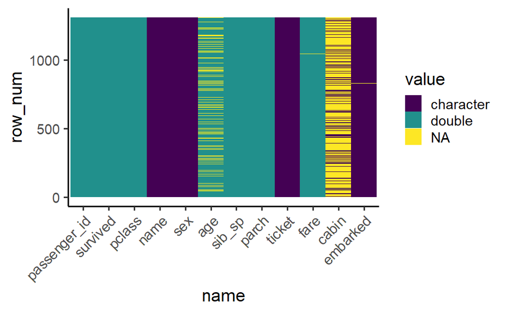

```r
return_dtype <- function(x) {
  if(is.na(x)) {
    return("NA")
  }
  return(typeof(x))
}
return_dtype_vector <- function(x) {
  sapply(x, return_dtype)
}

titanic |>
  mutate(across(.fns = return_dtype_vector)) |>
  mutate(row_num = row_number()) |>
  pivot_longer(cols = !row_num) |>
  mutate(name = factor(name,
                       levels = names(titanic),
                       )) |>
  ggplot(aes(x = name, y = row_num, fill = value)) +
  geom_tile() +
  scale_fill_viridis_d() +
  theme(axis.text.x = element_text(angle = 45, hjust = 1))
```

## How many survived

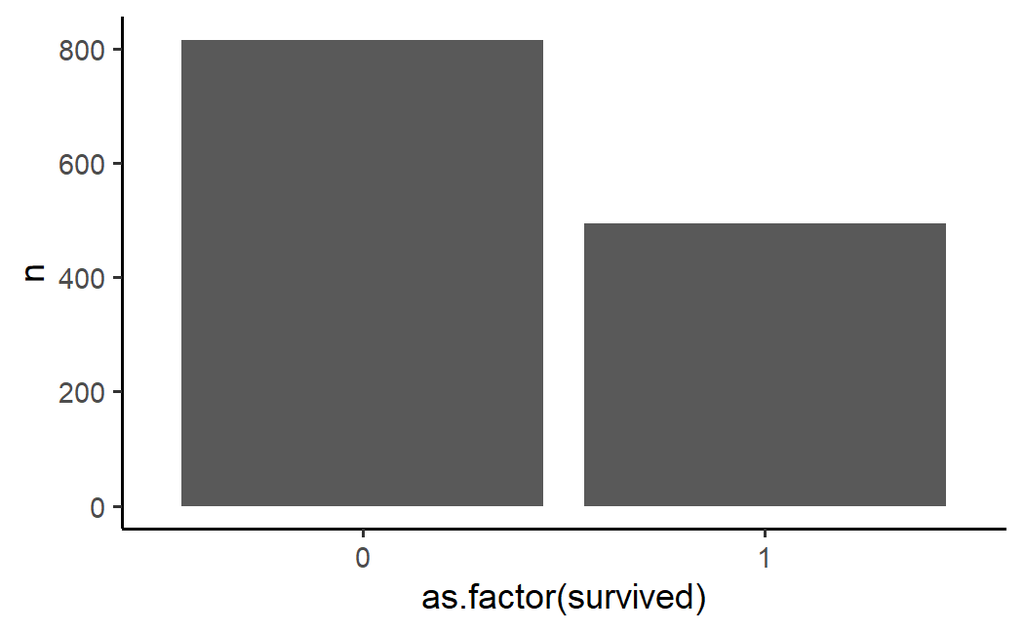

```r
titanic |>
  group_by(survived) |>
  summarise(n = n()) |>
  ggplot(aes(x = as.factor(survived), y = n)) +
  geom_bar(stat = "identity")
```

```r
titanic |>
  group_by(survived) |>
  summarise(n = n()) |>
  ungroup() |>
  mutate(t = sum(n),
         survived_percent = round(n/t*100, 2)
         ) |>
  select(survived, survived_percent) |>
  kbl() |>
  kable_classic()
```

| survived | survived_percent |
| --- | --- |
| 0 | 62.26 |
| 1 | 37.74 |

## Gender distribution

### Total

- More males onboard

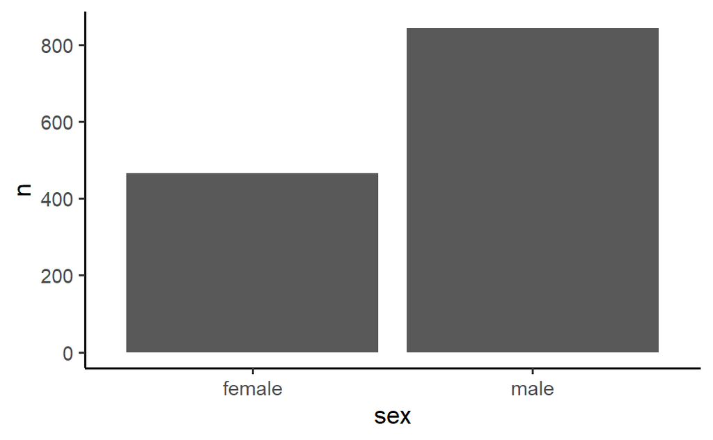

```r
titanic |>
  group_by(sex) |>
  summarise(n = n()) |>
  ggplot(aes(x = sex, y = n)) +
  geom_bar(stat = "identity")
```

### Survived

- More males died
- Higher & of males died

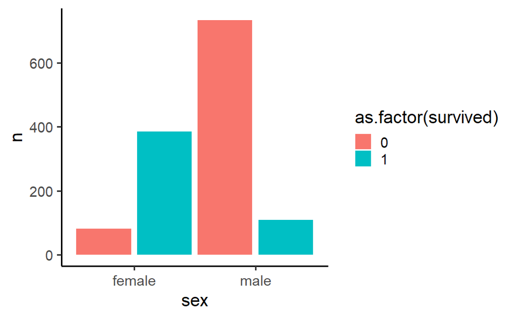

```r
titanic |>
  group_by(sex, survived) |>
  summarise(n = n()) |>
  ggplot(aes(x = sex, y = n, fill = as.factor(survived))) +
  geom_bar(stat = "identity", position = position_dodge(1))
```

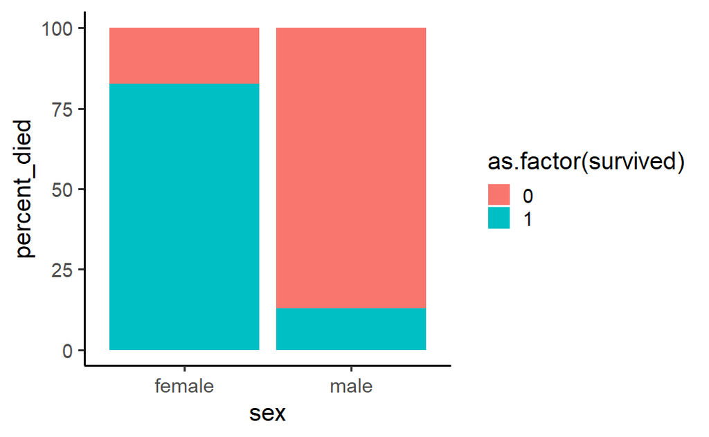

```r
titanic |>
  group_by(sex, survived) |>
  summarise(n = n()) |>
  ungroup() |>
  group_by(sex) |>
  mutate(t = sum(n)) |>
  ungroup() |>
  mutate(percent_died = n/t*100) |>
  ggplot(aes(x = sex, y = percent_died, fill = as.factor(survived))) +
  geom_bar(stat = "identity")
```

## Class distribution

### Total

- Equal class 1 & 2, more class 3

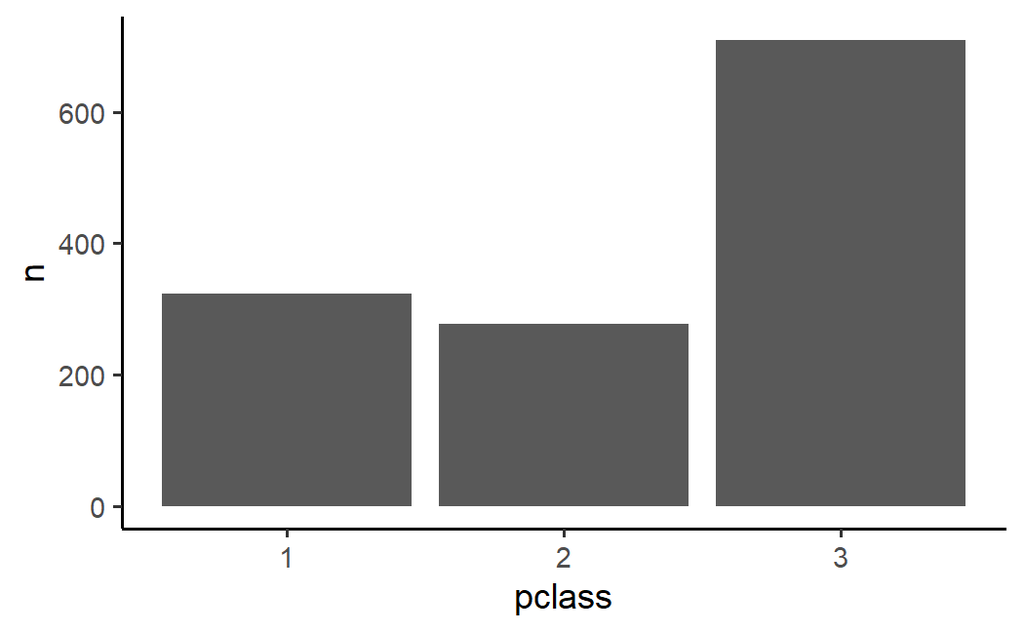

```r
titanic |>
  group_by(pclass) |>
  summarise(n = n()) |>
  ggplot(aes(x = pclass, y = n)) +
  geom_bar(stat = "identity")
```

### Survived

- As expected, higher class passengers have a higher % chance of survival

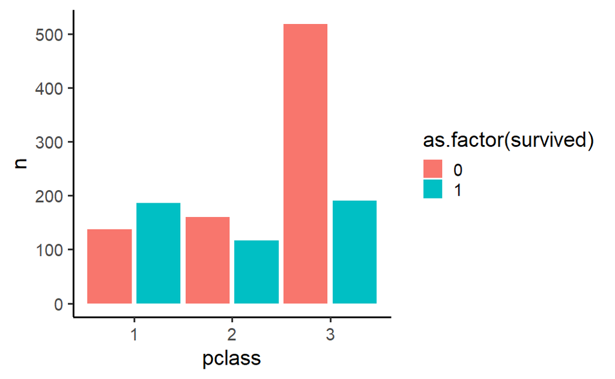

```r
titanic |>
  group_by(pclass, survived) |>
  summarise(n = n()) |>
  ggplot(aes(x = pclass, y = n, fill = as.factor(survived))) +
  geom_bar(stat = "identity", position = position_dodge(1))
```

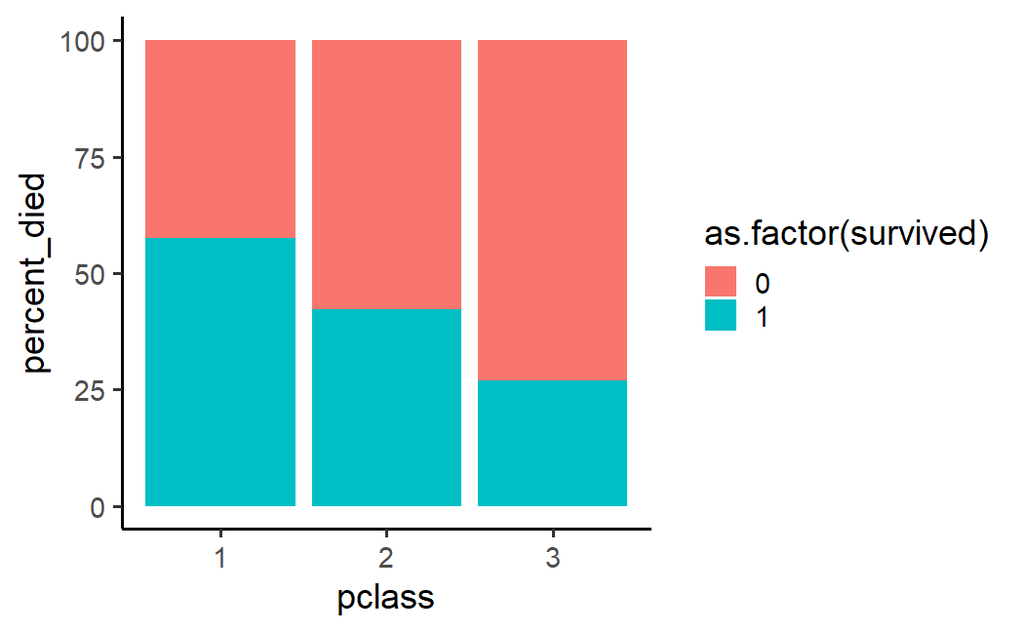

```r
titanic |>
  group_by(pclass, survived) |>
  summarise(n = n()) |>
  ungroup() |>
  group_by(pclass) |>
  mutate(t = sum(n)) |>
  ungroup() |>
  mutate(percent_died = n/t*100) |>
  ggplot(aes(x = pclass, y = percent_died, fill = as.factor(survived))) +
  geom_bar(stat = "identity")
```

## Numbers at age

### Total

- 263 missing ages, sad

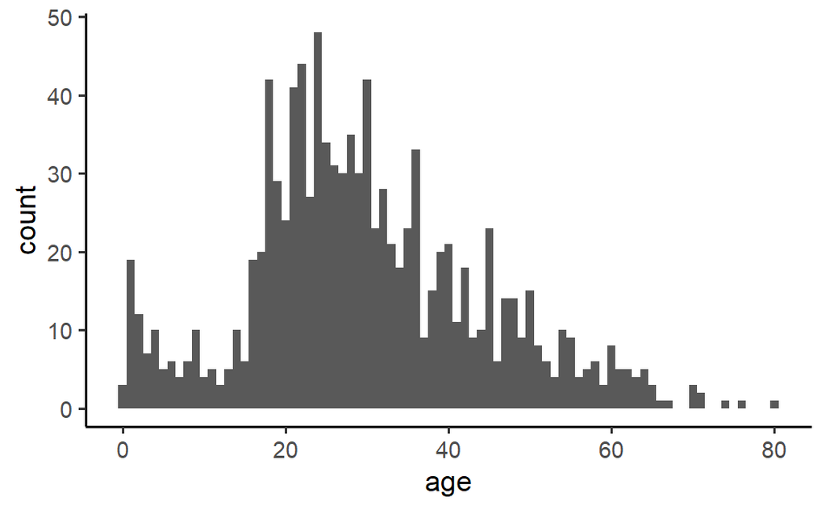

```r
titanic |>
  ggplot(aes(x = age)) +
  geom_histogram(binwidth = 1)
```

### Survived

- Really interesting non-linear interaction with age here.
- Probably too many to impute. Will have to decide based on model accuracy if we should include this or not.

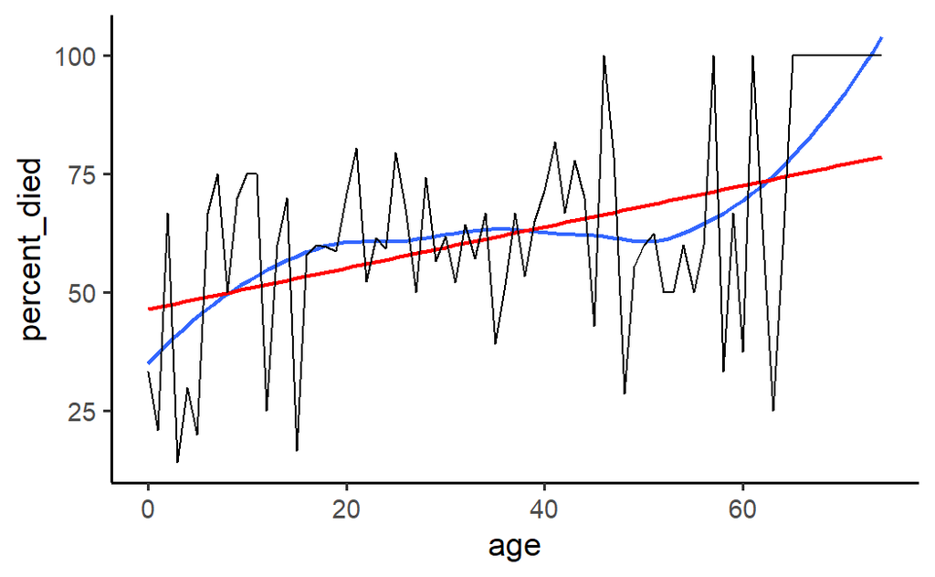

```r
titanic |>
  mutate(age = round(age, 0)) |>
  group_by(age, survived) |>
  summarise(n = n()) |>
  ungroup() |>
  group_by(age) |>
  mutate(t = sum(n)) |>
  ungroup() |>
  mutate(percent_died = n/t*100) |>
  filter(survived == 0) |>
  ggplot(aes(x = age, y = percent_died)) +
  geom_smooth(se = F) +
  geom_smooth(se = F, method = "lm", colour = "red") +
  geom_line()
```

## Number siblings/spouces

### Total

- Not a lot in higher sibling counts

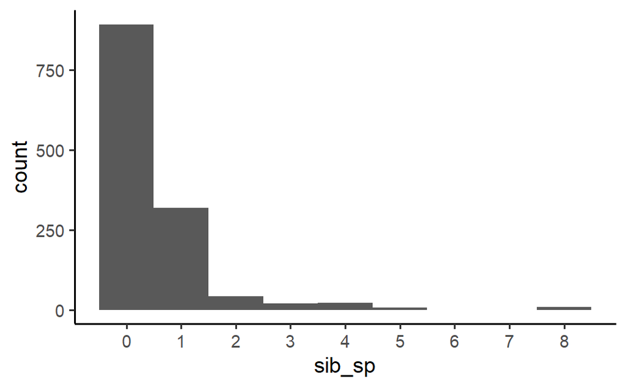

```r
titanic |>
  ggplot(aes(x = sib_sp)) +
  geom_histogram(binwidth = 1) +
  scale_x_continuous(breaks = seq(0, 9, 1), labels = seq(0, 9, 1))
```

### Survived

- Looks very good, but probably due to low samples in higher sibling counts
- Limiting it to 2 siblings shows strong fit, but this could be correlated with other things. Lets see later on.

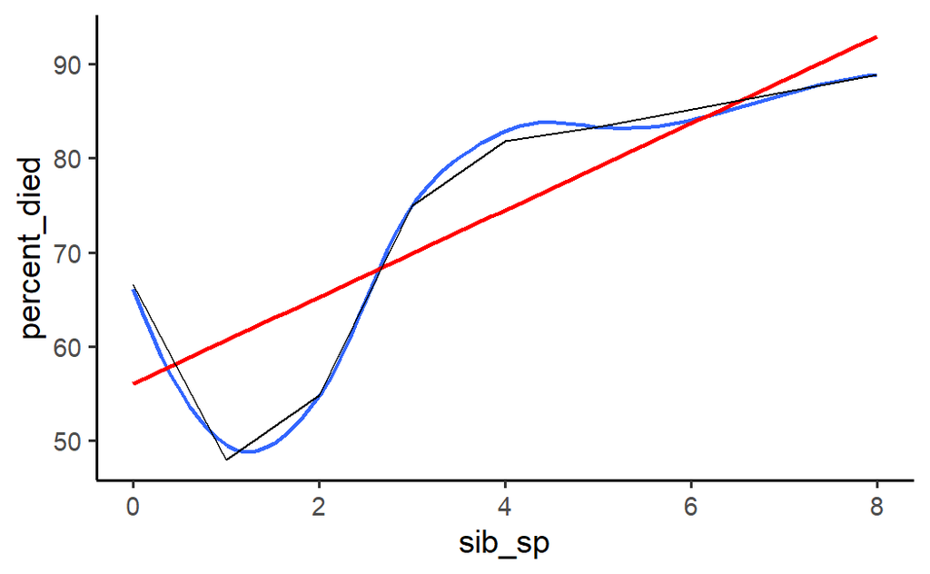

```r
titanic |>
  # mutate(age = round(age, 0)) |>
  group_by(sib_sp, survived) |>
  summarise(n = n()) |>
  ungroup() |>
  group_by(sib_sp) |>
  mutate(t = sum(n)) |>
  ungroup() |>
  mutate(percent_died = n/t*100) |>
  filter(survived == 0) |>
  ggplot(aes(x = sib_sp, y = percent_died)) +
  geom_smooth(se = F) +
  geom_smooth(se = F, method = "lm", colour = "red") +
  geom_line()
```

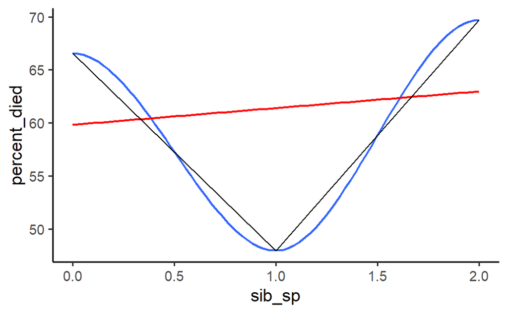

```r
titanic |>
  mutate(sib_sp = ifelse(sib_sp>=2, 2, sib_sp)) |>
  group_by(sib_sp, survived) |>
  summarise(n = n()) |>
  ungroup() |>
  group_by(sib_sp) |>
  mutate(t = sum(n)) |>
  ungroup() |>
  mutate(percent_died = n/t*100) |>
  filter(survived == 0) |>
  ggplot(aes(x = sib_sp, y = percent_died)) +
  geom_smooth(se = F) +
  geom_smooth(se = F, method = "lm", colour = "red") +
  geom_line()
```

## Number parents/children

### Total

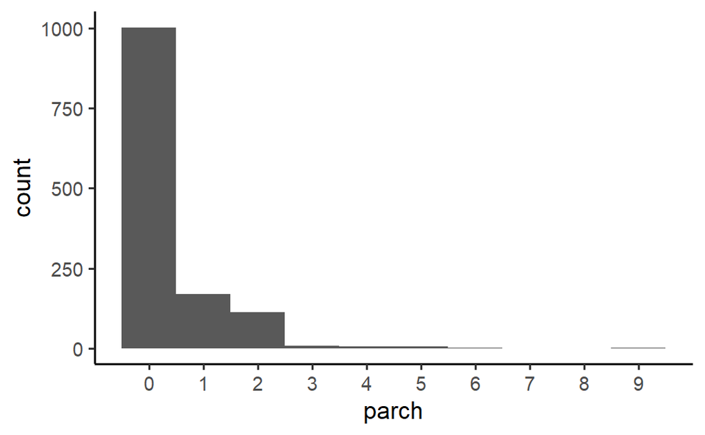

```r
titanic |>
  ggplot(aes(x = parch)) +
  geom_histogram(binwidth = 1) +
  scale_x_continuous(breaks = seq(0, 9, 1), labels = seq(0, 9, 1))
```

### Survived

- Same as siblings/spoices onboard, low sample sizes show good fit
- Lets check for correlation with other things before incusion
- Could be a good fit though

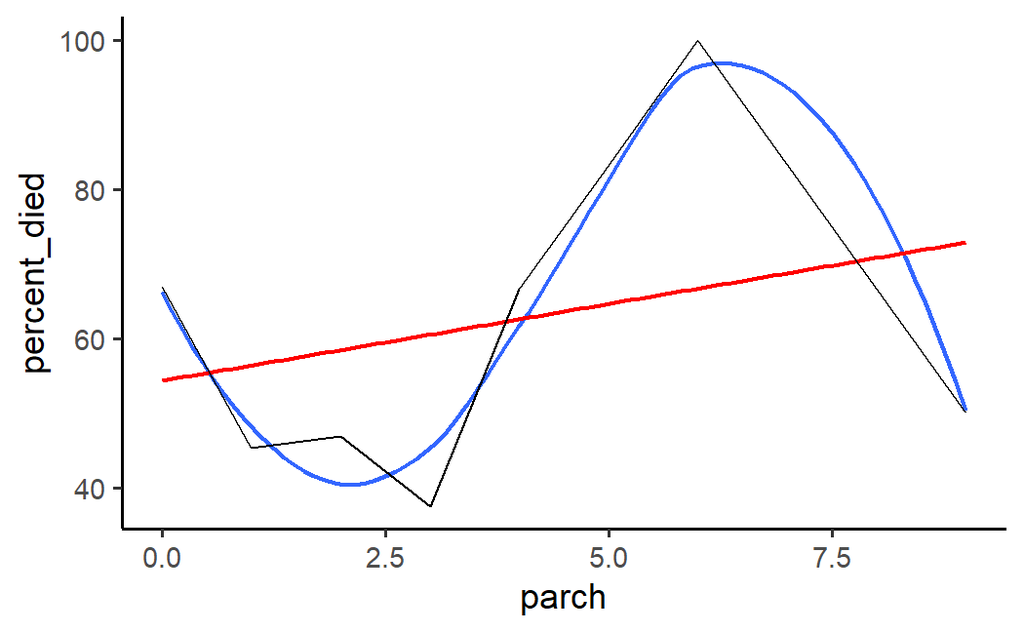

```r
titanic |>
  # mutate(age = round(age, 0)) |>
  group_by(parch, survived) |>
  summarise(n = n()) |>
  ungroup() |>
  group_by(parch) |>
  mutate(t = sum(n)) |>
  ungroup() |>
  mutate(percent_died = n/t*100) |>
  filter(survived == 0) |>
  ggplot(aes(x = parch, y = percent_died)) +
  geom_smooth(se = F) +
  geom_smooth(se = F, method = "lm", colour = "red") +
  geom_line()
```

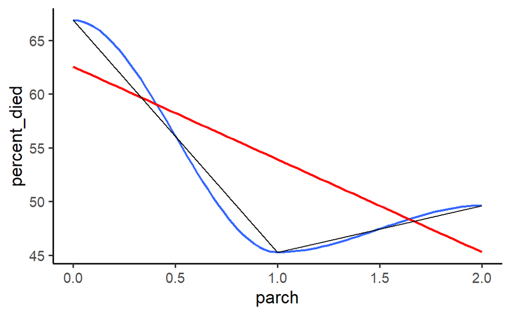

```r
titanic |>
  mutate(parch = ifelse(parch>=2, 2, parch)) |>
  group_by(parch, survived) |>
  summarise(n = n()) |>
  ungroup() |>
  group_by(parch) |>
  mutate(t = sum(n)) |>
  ungroup() |>
  mutate(percent_died = n/t*100) |>
  filter(survived == 0) |>
  ggplot(aes(x = parch, y = percent_died)) +
  geom_smooth(se = F) +
  geom_smooth(se = F, method = "lm", colour = "red") +
  geom_line()
```

## Fare distribution

### Total

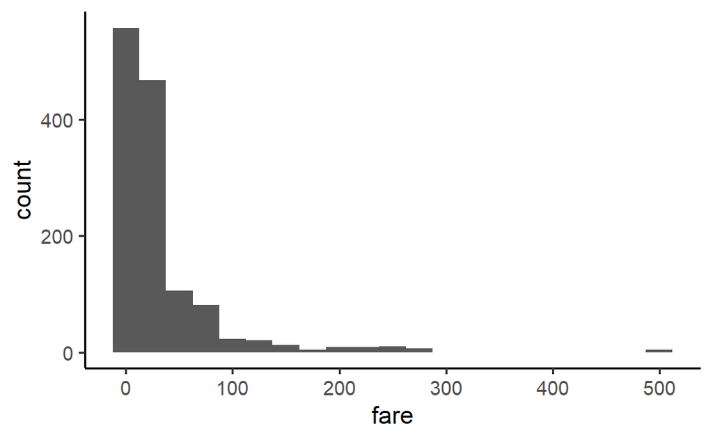

```r
titanic |>
  ggplot(aes(x = fare)) +
  geom_histogram(binwidth = 25)
```

### Survived

- Fare, as expected, shows a good relationship with % died
- Capping at £100 will help with low sample sizes for larger fares
- Will correlate with class, easier to use these continuous variables comapred to factors in models

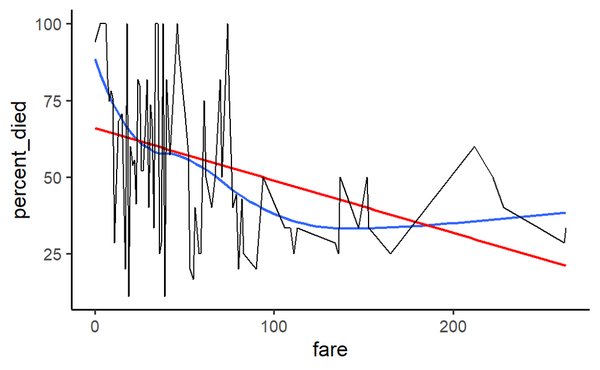

```r
titanic |>
  mutate(fare = round(fare, 0)) |>
  group_by(fare, survived) |>
  summarise(n = n()) |>
  ungroup() |>
  group_by(fare) |>
  mutate(t = sum(n)) |>
  ungroup() |>
  mutate(percent_died = n/t*100) |>
  filter(survived == 0) |>
  ggplot(aes(x = fare, y = percent_died)) +
  geom_smooth(se = F) +
  geom_smooth(se = F, method = "lm", colour = "red") +
  geom_line()
```

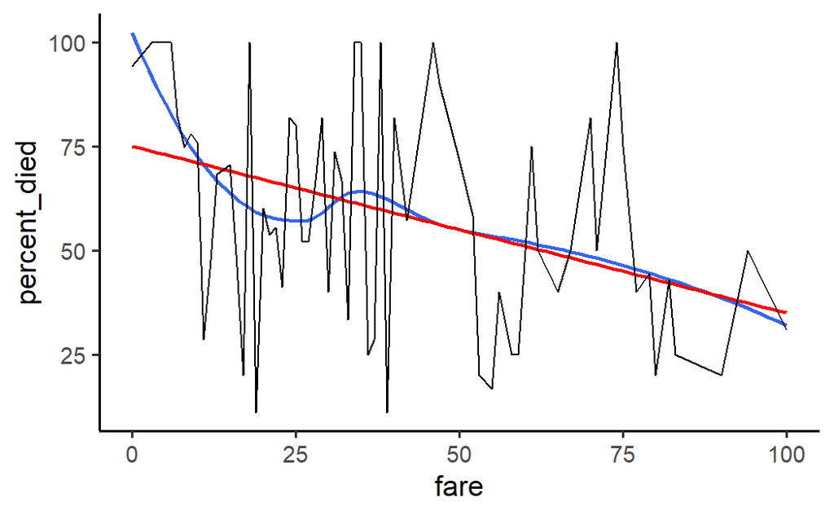

```r
titanic |>
  mutate(fare = round(fare, 0)) |>
  mutate(fare = ifelse(fare>=100, 100, fare)) |>
  group_by(fare, survived) |>
  summarise(n = n()) |>
  ungroup() |>
  group_by(fare) |>
  mutate(t = sum(n)) |>
  ungroup() |>
  mutate(percent_died = n/t*100) |>
  filter(survived == 0) |>
  ggplot(aes(x = fare, y = percent_died)) +
  geom_smooth(se = F) +
  geom_smooth(se = F, method = "lm", colour = "red") +
  geom_line()
```

## Correlation plots

```r
cor_matrix <- titanic |>
  filter(!is.na(fare)) |>
  filter(!is.na(age)) |>
  mutate(sex = ifelse(sex == "male", 1, 0)) |>
  select(survived, pclass, sex, age, sib_sp, parch, fare) |>
  cor()

cor_matrix |>
  round(2) |>
  head() |>
  kbl() |>
  kable_classic()
```

|  | survived | pclass | sex | age | sib_sp | parch | fare |
| --- | --- | --- | --- | --- | --- | --- | --- |
| survived | 1.00 | -0.28 | -0.68 | -0.05 | 0.01 | 0.12 | 0.24 |
| pclass | -0.28 | 1.00 | 0.14 | -0.41 | 0.05 | 0.02 | -0.57 |
| sex | -0.68 | 0.14 | 1.00 | 0.06 | -0.09 | -0.22 | -0.19 |
| age | -0.05 | -0.41 | 0.06 | 1.00 | -0.24 | -0.15 | 0.18 |
| sib_sp | 0.01 | 0.05 | -0.09 | -0.24 | 1.00 | 0.37 | 0.14 |
| parch | 0.12 | 0.02 | -0.22 | -0.15 | 0.37 | 1.00 | 0.22 |

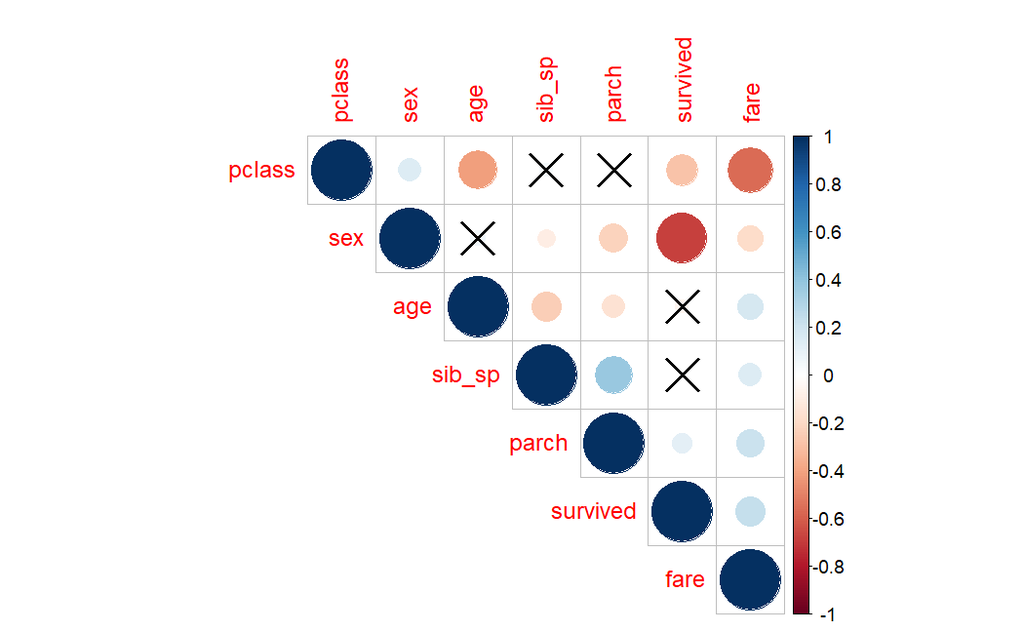

```r
cor.mtest <- function(mat, ...) {
    mat <- as.matrix(mat)
    n <- ncol(mat)
    p.mat<- matrix(NA, n, n)
    diag(p.mat) <- 0
    for (i in 1:(n - 1)) {
        for (j in (i + 1):n) {
            tmp <- cor.test(mat[, i], mat[, j], ...)
            p.mat[i, j] <- p.mat[j, i] <- tmp$p.value
        }
    }
  colnames(p.mat) <- rownames(p.mat) <- colnames(mat)
  p.mat
}
# matrix of the p-value of the correlation
p.mat <- titanic |>
  filter(!is.na(fare)) |>
  filter(!is.na(age)) |>
  mutate(sex = ifelse(sex == "male", 1, 0)) |>
  select(survived, pclass, sex, age, sib_sp, parch, fare) |>
  cor.mtest()

corrplot(cor_matrix, type="upper", order="hclust",
         p.mat = p.mat, sig.level = 0.01)
```

## Data exploration lessons learned

- Inclusion of sex, fare & parch essential
- Age has interesting non-liner, but lots of missing data so may be worth not including it
- sib_sp may have some non-linear relationship